# Project Week 2

Ananda Putra Wijaya/G1401221111

2024-08-30

# Inisiasi *library*

```r
library(dplyr)
library(TTR)
library(forecast)
library(lmtest)
library(orcutt)
library(HoRM)
library(readxl)
```

# Inisiasi data

```r
DataW2<-as.data.frame(read_xlsx("C:/Tugas/Semester 5/Metode Peramalan Deret Waktu/Minggu 2/Data Project Week 2.xlsx"))
DataW2$Tahun <- as.numeric(DataW2$Tahun)

DataW2
```

```
##    Tahun        PDB
## 1   1960   84466653
## 2   1961   89249985
## 3   1962   94149984
## 4   1963   96366651
## 5   1964  107566649
## 6   1965  114339050
## 7   1966  134173375
## 8   1967  155102980
## 9   1968  150000000
## 10  1969  164900000
## 11  1970  186300000
## 12  1971  211100000
## 13  1972  235400000
## 14  1973  269500000
```

[output cut: 49 more lines]

```r
Tahun<-as.numeric(DataW2$Tahun)
PDB<-DataW2$PDB
```

# Transformasi data PDB menjadi *time series*

```r
DataW2ts<-ts(DataW2$PDB)
DataW2ts
```

```
## Time Series:
## Start = 1
## End = 63
## Frequency = 1
##  [1]   84466653   89249985   94149984   96366651  107566649  114339050
##  [7]  134173375  155102980  150000000  164900000  186300000  211100000
## [13]  235400000  269500000  312600000  345000000  386300000  447000000
## [19]  475800000  517200000  613299968  739100032  785500032  889400000
## [25]  985699968 1039500032 1173500032 1296499968 1415100032 1501500032
## [31] 1592400000 1634900000 1679900000 1820359900 1867160100 2030750000
## [37] 2695390000 2932827000 3130748000 3324433000 3480219000 3680483000
## [43] 3937228000 4186525000 4484703000 4868136000 6144000000 6767000000
## [49] 6980000000 6656000000 6634526000 6312691000 6378188000 6465756000
## [55] 6413988000 6654541000 6899911000 7142316000 7225977000 7423465000
## [61] 6887147000 7286607000 7827980000
```

# *Plot* awal data PDB

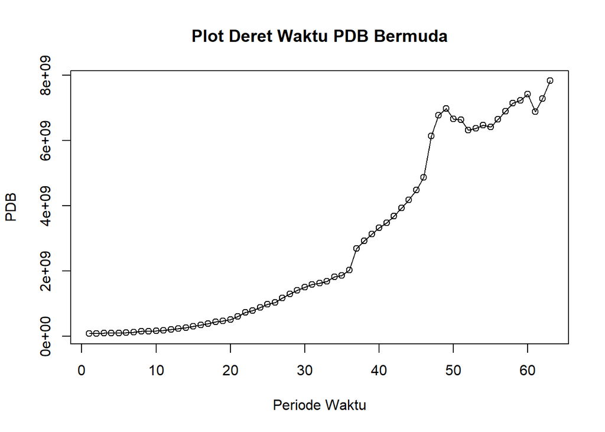

```r
ts.plot(DataW2ts, xlab="Periode Waktu", ylab="PDB", main= "Plot Deret Waktu PDB Bermuda")
points(DataW2ts)
```

# Peramalan menggunakan DMA

```r
datasma <- SMA(DataW2ts, n=3)
dma <- SMA(datasma, n = 3)
At <- 2*datasma - dma
Bt <- 2/(3-1)*(datasma - dma)
datadma<- At+Bt
dmaramal<- c(NA, datadma)

t = 1:5
f = c()

for (i in t) {
  f[i] = At[length(At)] + Bt[length(Bt)]*(i)
}
```

## *Plot* DMA

```r
datagab <- cbind(
  aktual = c(DataW2ts, rep(NA, 5)),
  pemulusan1 = c(datasma, rep(NA, 5)),
  pemulusan2 = c(datadma, rep(NA, 5)),
  At = c(At, rep(NA, 5)),
  Bt = c(Bt, rep(NA, 5)),
  ramalan = c(dmaramal, f[-1])
)
datagab
```

```
##           aktual pemulusan1 pemulusan2         At         Bt    ramalan
##  [1,]   84466653         NA         NA         NA         NA         NA
##  [2,]   89249985         NA         NA         NA         NA         NA
##  [3,]   94149984   89288874         NA         NA         NA         NA
##  [4,]   96366651   93255540         NA         NA         NA         NA
##  [5,]  107566649   99361095  110146278  104753686    5392592         NA
##  [6,]  114339050  106090783  119134071  112612427    6521644  110146278
##  [7,]  134173375  118693025  139982473  129337749   10644724  119134071
##  [8,]  155102980  134538469  164067221  149302845   14764376  139982473
##  [9,]  150000000  146425452  172838392  159631922   13206470  164067221
## [10,]  164900000  156667660  178248593  167458127   10790467  172838392
## [11,]  186300000  167066667  187760148  177413407   10346740  178248593
## [12,]  211100000  187433333  221521560  204477447   17044113  187760148
## [13,]  235400000  210933333  255844444  233388889   22455556  221521560
## [14,]  269500000  238666667  291311111  264988889   26322222  255844444
```

[output cut: 54 more lines]

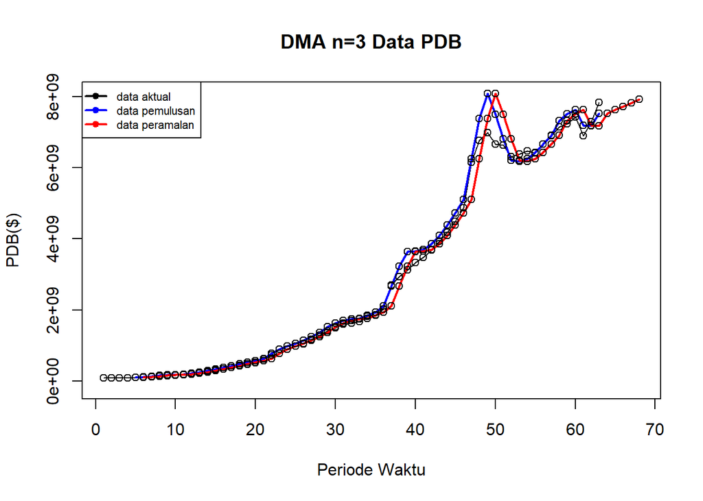

```r
ts.plot(datagab[, 1], xlab = "Periode Waktu", ylab = "PDB($)",
        main = "DMA n=3 Data PDB", ylim = c(min(datagab, na.rm = TRUE), max(datagab, na.rm = TRUE)))

lines(datagab[, 3], col = "blue", lwd = 2)
lines(datagab[, 6], col = "red", lwd = 2)
points(datagab[, 1], col = "black", pch = 21, bg = NA)
points(datagab[, 3], col = "black", pch = 21, bg = NA)
points(datagab[, 6], col = "black", pch = 21, bg = NA)

legend("topleft", c("data aktual", "data pemulusan", "data peramalan"),
       col = c("black", "blue", "red"), lty = c(1, 1, 1), lwd = 2, pch = 21, pt.bg = NA, cex = 0.7)
```

## Menghitung akurasi DMA

```r
error.dma = DataW2ts-dmaramal[1:length(DataW2ts)]
SSE.dma = sum(error.dma[6:length(DataW2ts)]^2)
MSE.dma = mean(error.dma[6:length(DataW2ts)]^2)
MAPE.dma = mean(abs((error.dma[6:length(DataW2ts)]/DataW2ts[6:length(DataW2ts)])*100))

akurasi.dma <- matrix(c(SSE.dma, MSE.dma, MAPE.dma))
row.names(akurasi.dma)<- c("SSE", "MSE", "MAPE")
colnames(akurasi.dma) <- c("Akurasi m = 3")
akurasi.dma
```

```
##      Akurasi m = 3
## SSE   6.474255e+18
## MSE   1.116251e+17
## MAPE  5.369022e+00
```

# Peramalan menggunakan DES

## Pembagian data latih dan uji untuk metode DES

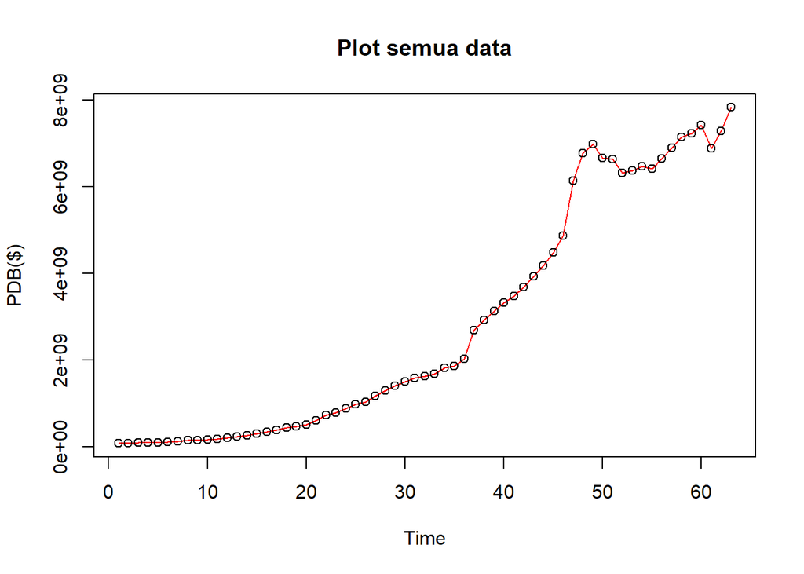

```r
DataW2ts.lat <- unlist(DataW2[1:50,2])
DataW2ts.uji <- unlist(DataW2[51:63,2])

latw2ts<-ts(DataW2ts.lat)
uji2w2ts<-ts(DataW2ts.uji,start=51)

plot(DataW2ts,ylab="PDB($)", col="red",main="Plot semua data")
points(DataW2ts)
```

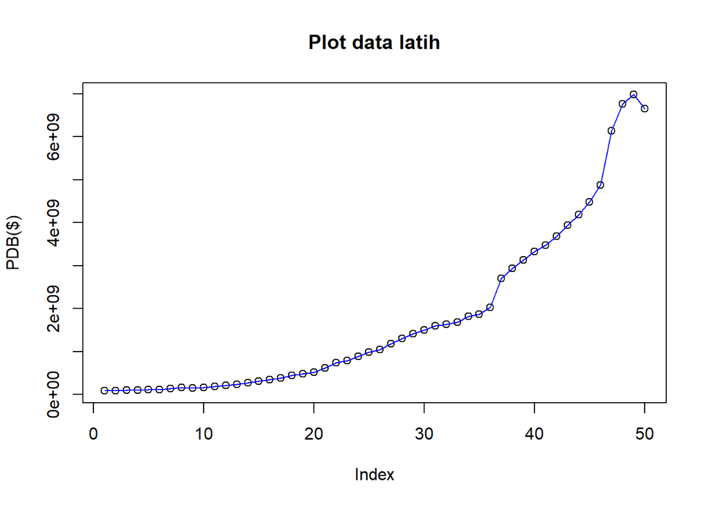

```r
plot(DataW2ts.lat,ylab="PDB($)", main = "Plot data latih", type = "p")
points(DataW2ts.lat, col="black")
lines(DataW2ts.lat,col="blue")
```

## Pemulusan DES

```r
desopt<- HoltWinters(DataW2ts.lat, gamma = FALSE)
desopt
```

```
## Holt-Winters exponential smoothing with trend and without seasonal component.
##
## Call:
## HoltWinters(x = DataW2ts.lat, gamma = FALSE)
##
## Smoothing parameters:
##  alpha: 1
##  beta : 0.8562485
##  gamma: FALSE
##
## Coefficients:
##         [,1]
## a 6656000000
## b -236780389
```

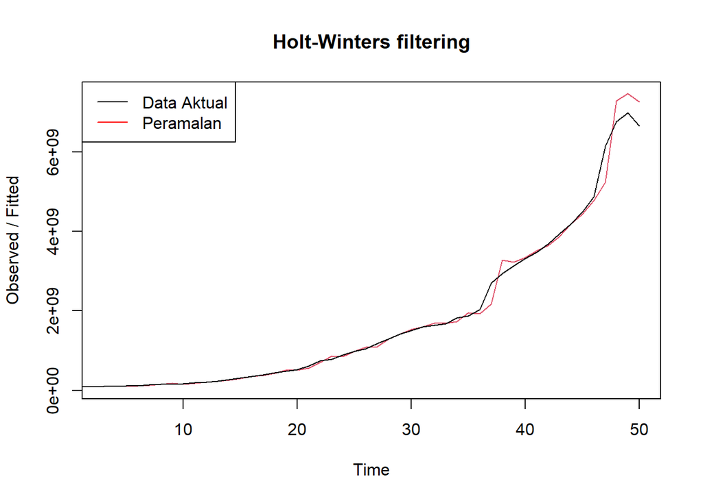

```r
plot(desopt)
legend("topleft", c("Data Aktual", "Peramalan"), col = c("black", "red"),
       lty = c(1,1))
```

```r
ramaldesopt<- forecast(desopt, h=13)
ramaldesopt
```

```
##    Point Forecast       Lo 80       Hi 80       Lo 95       Hi 95
## 51     6419219611  6144157979  6694281243  5998549146  6839890076
## 52     6182439222  5602479191  6762399254  5295466895  7069411549
## 53     5945658833  5000659047  6890658620  4500406378  7390911289
## 54     5708878444  4346302882  7071454007  3624998950  7792757938
## 55     5472098055  3645063101  7299133009  2677889219  8266306892
## 56     5235317667  2901158575  7569476758  1665529391  8805105942
## 57     4998537278  2117864028  7879210528   592927724  9404146832
## 58     4761756889  1297808818  8225704959  -535894525 10059408302
## 59     4524976500   443161629  8606791370 -1717620640 10767573640
## 60     4288196111  -444250187  9020642409 -2949455930 11525848152
## 61     4051415722 -1362860094  9465691538 -4229004580 12331836024
## 62     3814635333 -2311305978  9940576645 -5554183421 13183454087
## 63     3577854944 -3288389399 10444099287 -6923159594 14078869483
```

## Akurasi DES data latih

```r
ssedes.train<-desopt$SSE
msedes.train<-ssedes.train/length(latw2ts)
sisaandes<-ramaldesopt$residuals
head(sisaandes)
```

```
## Time Series:
## Start = 1
## End = 6
## Frequency = 1
## [1]         NA         NA   116666.6 -2666561.9  8600009.6 -3191332.3
```

```r
mapedes.train <- sum(abs(sisaandes[3:length(latw2ts)]/latw2ts[3:length(latw2ts)])*100)/length(latw2ts)

akurasides.opt <- matrix(c(ssedes.train,msedes.train,mapedes.train))
row.names(akurasides.opt)<- c("SSE", "MSE", "MAPE")
colnames(akurasides.opt) <- c("Akurasi lamda dan gamma optimum")
akurasides.opt
```

```
##      Akurasi lamda dan gamma optimum
## SSE                     2.166797e+18
## MSE                     4.333594e+16
## MAPE                    4.452996e+00
```

## Akurasi DES data uji

```r
selisihdesopt<-ramaldesopt$mean-uji2w2ts


SSEtestingdesopt<-sum(selisihdesopt^2)
SSEtestingdesopt<-SSEtestingdesopt/length(uji2w2ts)
MAPEtestingdesopt<-sum(abs(selisihdesopt/uji2w2ts)*100)/length(uji2w2ts)

akurasiDesTesting <- matrix(c(SSEtestingdesopt,SSEtestingdesopt,MAPEtestingdesopt))
row.names(akurasiDesTesting)<- c("SSE", "MSE", "MAPE")
colnames(akurasiDesTesting) <- c("Akurasi lamda dan gamma optimum")
akurasiDesTesting
```

```
##      Akurasi lamda dan gamma optimum
## SSE                     5.253211e+18
## MSE                     5.253211e+18
## MAPE                    2.641734e+01
```

## Perbandingan akurasi DMA dengan DES

```r
cbind(akurasi.dma, akurasides.opt)
```

```
##      Akurasi m = 3 Akurasi lamda dan gamma optimum
## SSE   6.474255e+18                    2.166797e+18
## MSE   1.116251e+17                    4.333594e+16
## MAPE  5.369022e+00                    4.452996e+00
```

Berdasarkan nilai akurasi SSE, MSE, dan MAPE, metode DES memiliki nilai-nilai akurasi yang lebih kecil daripada metode DMA. Hal ini membuat metode DES lebih baik daripada metode DMA.

# Eksplorasi Data

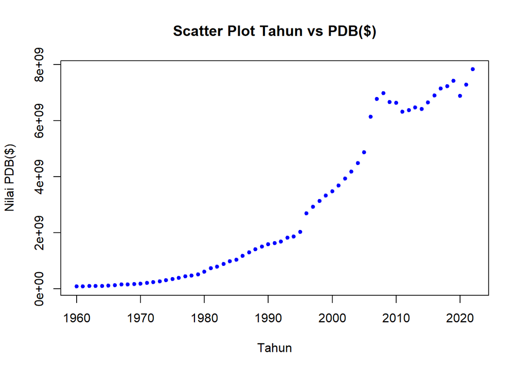

```r
plot(DataW2, pch = 20, col = "blue",
     main = "Scatter Plot Tahun vs PDB($)",
     xlab = "Tahun",
     ylab = "Nilai PDB($)")
```

```r
#Menampilkan Nilai Korelasi
cor(Tahun,DataW2$PDB)
```

```
## [1] 0.9474186
```

Berdasarkan plot antara tahun dengan nilai pdb, dapat kita lihat bahwa terdapat hubungan positif yang sangat erat. Hal ini juga diperkuat melalui perhitungan korelasi antara peubah tahun dengan nilai pdb, dengan nilai korelasi sebesar *0.9474186*. Nilai ini menunjukkan hubungan positif yang sangat erat.

# Model regresi

```r
modelreg<- lm(PDB~Tahun, data = DataW2)
summary(modelreg)
```

```
##
## Call:
## lm(formula = PDB ~ Tahun, data = DataW2)
##
## Residuals:
##        Min         1Q     Median         3Q        Max
## -1.389e+09 -7.179e+08 -3.650e+07  6.315e+08  1.749e+09
##
## Coefficients:
##               Estimate Std. Error t value Pr(>|t|)
## (Intercept) -2.780e+11  1.215e+10  -22.89   <2e-16 ***
## Tahun        1.411e+08  6.100e+06   23.12   <2e-16 ***
## ---
## Signif. codes:  0 '***' 0.001 '**' 0.01 '*' 0.05 '.' 0.1 ' ' 1
##
## Residual standard error: 880500000 on 61 degrees of freedom
## Multiple R-squared:  0.8976, Adjusted R-squared:  0.8959
## F-statistic: 534.7 on 1 and 61 DF,  p-value: < 2.2e-16
```

Model yang dihasilkan adalah
$$y_i=-278030155234 + 141066240 x_t$$
. Dari hasil ringkasan model, uji F model memiliki *p-value* < $\alpha$ (5%), artinya, terdapat minimal satu variabel yang berpengaruh signifikan terhadap model. Hasil uji-t parsial kedua parameter regresi, yaitu intersep dan koefisien regresi juga menunjukkan hal yang sama, yaitu memiliki *p-value* < $\alpha$ (5%) sehingga nyata dalam taraf 5%. Selanjutnya dapat dilihat juga nilai $R^2=0.8976$. Artinya, sebesar 89.76% keragaman nilai PDB dapat dijelaskan oleh peubah tahun. Selanjutnya akan dilakukan pengujian terhadap sisaan.

## Pengujian sisaan model

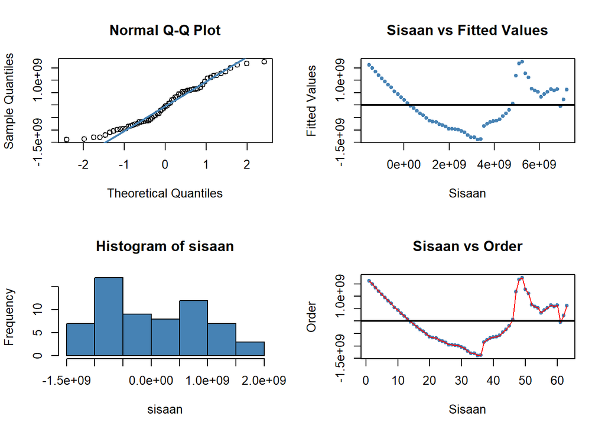

```r
sisaan<- residuals(modelreg)
fitValue<- predict(modelreg)

par(mfrow = c(2,2))
qqnorm(sisaan)
qqline(sisaan, col = "steelblue", lwd = 2)
plot(fitValue, sisaan, col = "steelblue", pch = 20, xlab = "Sisaan", ylab = "Fitted Values", main = "Sisaan vs Fitted Values")
abline(a = 0, b = 0, lwd = 2)
hist(sisaan, col = "steelblue")
plot(seq(1,63,1), sisaan, col = "steelblue", pch = 20, xlab = "Sisaan", ylab = "Order", main = "Sisaan vs Order")
lines(seq(1,63,1), sisaan, col = "red")
abline(a = 0, b = 0, lwd = 2)
```

## Uji formal

### Uji normalitas

```r
shapiro.test(sisaan)
```

```
##
##  Shapiro-Wilk normality test
##
## data:  sisaan
## W = 0.95621, p-value = 0.02505
```

```r
ks.test(sisaan, "pnorm", mean=mean(sisaan), sd=sd(sisaan))
```

```
##
##  Exact one-sample Kolmogorov-Smirnov test
##
## data:  sisaan
## D = 0.11107, p-value = 0.3901
## alternative hypothesis: two-sided
```

H0: sisaan mengikuti sebaran normal, H1: sisaan tidak mengikuti sebaran normal.

### Uji ACF dan PACF

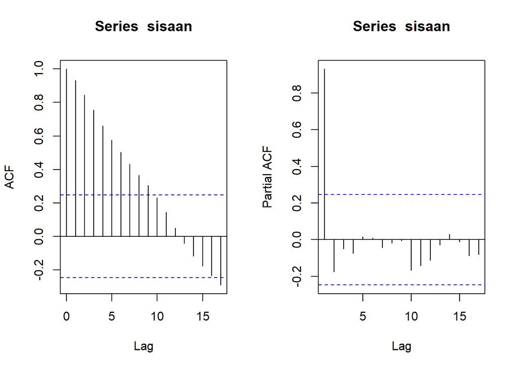

```r
par(mfrow = c(1,2))
acf(sisaan)
pacf(sisaan)
```

### Uji Durbin Watson

```r
dwtest(modelreg)
```

```
##
##  Durbin-Watson test
##
## data:  modelreg
## DW = 0.073605, p-value < 2.2e-16
## alternative hypothesis: true autocorrelation is greater than 0
```

H0: tidak ada autokorelasi, H1: ada autokorelasi.

Berdasarkan uji Durbin Watson yang telah dilakukan, diperoleh nilai p sebesar 2.2e-16 < $=$5%. Kesimpulan yang dapat diambil adalah pada taraf nyata 5%, tolak H0, artinya terdapat autokorelasi, sehingga diperlukan penanganan untuk autokorelasi tersebut. Penanganan autokorelasi yang akan dilakukan adalah metode Cochrane-Orcutt dan Hildret-Lu.

# Penanganan Autokorelasi

## Metode Cochrane-Orcutt

```r
modelCO<-cochrane.orcutt(modelreg)
modelCO
```

```
## Cochrane-orcutt estimation for first order autocorrelation
##
## Call:
## lm(formula = PDB ~ Tahun, data = DataW2)
##
##  number of interaction: 44
##  rho 0.940121
##
## Durbin-Watson statistic
## (original):    0.07361 , p-value: 2.389e-40
## (transformed): 1.27215 , p-value: 9.071e-04
##
##  coefficients:
##   (Intercept)         Tahun
## -395823454080     199612066
```

```r
rho<-modelCO$rho
```

Model yang didapat dari metode Cochrane-Orcutt adalah
$$y_i=-395823454080 + 199612066 x_t$$
. Metode Cocharane-Orcutt juga menunjukkan bahwa nilai DW dan p-value meningkat menjadi $1.27215$ dan $0.0009071$. Namun nilai DW tidak berada pada rentang DU < DW < 4-DU, melainkan masih berada dalam rentang DW<DL atau $1.27215<1.5599$. Nilai p juga masih lebih kecil daripada taraf nyata $=$5%. Artinya, masih tolak H0, yang mana masih terdapat autokorelasi pada taraf nyata 5%.

### Transformasi data

```r
PDB
```

```
##  [1]   84466653   89249985   94149984   96366651  107566649  114339050
##  [7]  134173375  155102980  150000000  164900000  186300000  211100000
## [13]  235400000  269500000  312600000  345000000  386300000  447000000
## [19]  475800000  517200000  613299968  739100032  785500032  889400000
## [25]  985699968 1039500032 1173500032 1296499968 1415100032 1501500032
## [31] 1592400000 1634900000 1679900000 1820359900 1867160100 2030750000
## [37] 2695390000 2932827000 3130748000 3324433000 3480219000 3680483000
## [43] 3937228000 4186525000 4484703000 4868136000 6144000000 6767000000
## [49] 6980000000 6656000000 6634526000 6312691000 6378188000 6465756000
## [55] 6413988000 6654541000 6899911000 7142316000 7225977000 7423465000
## [61] 6887147000 7286607000 7827980000
```

```r
PDB[-1]
```

```
##  [1]   89249985   94149984   96366651  107566649  114339050  134173375
##  [7]  155102980  150000000  164900000  186300000  211100000  235400000
## [13]  269500000  312600000  345000000  386300000  447000000  475800000
## [19]  517200000  613299968  739100032  785500032  889400000  985699968
## [25] 1039500032 1173500032 1296499968 1415100032 1501500032 1592400000
## [31] 1634900000 1679900000 1820359900 1867160100 2030750000 2695390000
## [37] 2932827000 3130748000 3324433000 3480219000 3680483000 3937228000
## [43] 4186525000 4484703000 4868136000 6144000000 6767000000 6980000000
## [49] 6656000000 6634526000 6312691000 6378188000 6465756000 6413988000
## [55] 6654541000 6899911000 7142316000 7225977000 7423465000 6887147000
## [61] 7286607000 7827980000
```

```r
PDBtrans<- PDB[-1]-PDB[-63]*rho
Tahuntrans<- Tahun[-1]-Tahun[-63]*rho
modelCOmanual<- lm(PDBtrans~Tahuntrans)
summary(modelCOmanual)
```

```
##
## Call:
## lm(formula = PDBtrans ~ Tahuntrans)
##
## Residuals:
##        Min         1Q     Median         3Q        Max
## -722148438  -72173368  -20025238   55490084 1104358984
##
## Coefficients:
##               Estimate Std. Error t value Pr(>|t|)
## (Intercept) -2.370e+10  3.209e+09  -7.387 5.47e-10 ***
## Tahuntrans   1.996e+08  2.670e+07   7.477 3.83e-10 ***
## ---
## Signif. codes:  0 '***' 0.001 '**' 0.01 '*' 0.05 '.' 0.1 ' ' 1
##
## Residual standard error: 225300000 on 60 degrees of freedom
## Multiple R-squared:  0.4823, Adjusted R-squared:  0.4737
## F-statistic: 55.91 on 1 and 60 DF,  p-value: 3.832e-10
```

```r
b0bintang <- modelCOmanual$coefficients[-2]
b0 <- b0bintang/(1-rho)
b1 <- modelCOmanual$coefficients[-1]
b0
```

```
##   (Intercept)
## -395823454080
```

```r
b1
```

```
## Tahuntrans
##  199612066
```

Hasil $β_0$dan$β_1$ sudah sama dengan jika menggunakan fungsi cochrane.orcutt(modelreg).

## Metode Hildreth-Lu

```r
HiLu.func<- function(r, modelreg){
  x <- model.matrix(modelreg)[,-1]
  y <- model.response(model.frame(modelreg))
  n <- length(y)
  t <- 2:n
  y <- y[t]-r*y[t-1]
  x <- x[t]-r*x[t-1]

  return(lm(y~x))
}

r <- c(seq(0.1,1, by= 0.1))
tab <- data.frame("rho" = r, "SSE" = sapply(r, function(i){deviance(HiLu.func(i, modelreg))}))
round(tab, 4)
```

```
##    rho          SSE
## 1  0.1 3.613161e+19
## 2  0.2 2.872360e+19
## 3  0.3 2.225317e+19
## 4  0.4 1.672033e+19
## 5  0.5 1.212505e+19
## 6  0.6 8.467362e+18
## 7  0.7 5.747248e+18
## 8  0.8 3.964713e+18
## 9  0.9 3.119757e+18
## 10 1.0 3.464694e+18
```

```r
rOpt <- seq(0.9,1.5, by= 0.001)
tabOpt <- data.frame("rho" = rOpt, "SSE" = sapply(rOpt, function(i){deviance(HiLu.func(i, modelreg))}))
head(tabOpt[order(tabOpt$SSE),])
```

```
##      rho          SSE
## 41 0.940 3.044296e+18
## 42 0.941 3.044332e+18
## 40 0.939 3.044355e+18
## 43 0.942 3.044461e+18
## 39 0.938 3.044507e+18
## 44 0.943 3.044684e+18
```

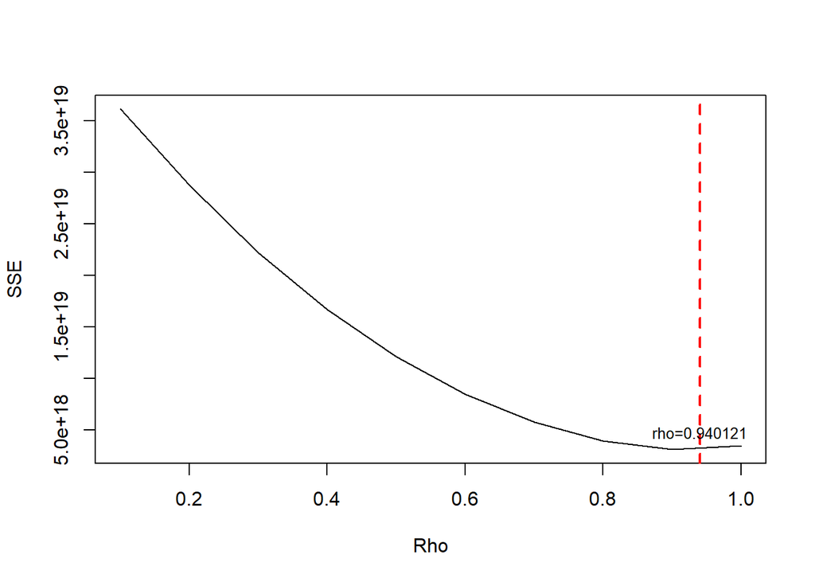

```r
#Grafik SSE optimum
par(mfrow = c(1,1))
plot(tab$SSE ~ tab$rho , type = "l", xlab = "Rho", ylab = "SSE")
abline(v = tabOpt[tabOpt$SSE==min(tabOpt$SSE),"rho"], lty = 2, col="red",lwd=2)
text(x=0.940121, y=4800000000000000000, labels = "rho=0.940121", cex = 0.8)
```

Perhitungan yang dilakukan aplikasi `R` menunjukkan bahwa nilai $ρ$ optimum, yaitu saat SSE terkecil terdapat pada nilai $ρ=0.9401$.

```r
modelHiLu <- HiLu.func(0.9401, modelreg)
summary(modelHiLu)
```

```
##
## Call:
## lm(formula = y ~ x)
##
## Residuals:
##        Min         1Q     Median         3Q        Max
## -722134105  -72182695  -20022439   55510975 1104360775
##
## Coefficients:
##               Estimate Std. Error t value Pr(>|t|)
## (Intercept) -2.371e+10  3.209e+09  -7.388 5.43e-10 ***
## x            1.996e+08  2.669e+07   7.479 3.80e-10 ***
## ---
## Signif. codes:  0 '***' 0.001 '**' 0.01 '*' 0.05 '.' 0.1 ' ' 1
##
## Residual standard error: 225300000 on 60 degrees of freedom
## Multiple R-squared:  0.4825, Adjusted R-squared:  0.4738
## F-statistic: 55.93 on 1 and 60 DF,  p-value: 3.804e-10
```

```r
#Transformasi Balik
cat("y = ", coef(modelHiLu)[1]/(1-0.9401), "+", coef(modelHiLu)[2],"x", sep = "")
```

```
## y = -395780908856+199591088x
```

Setelah melakukan transformasi balik, didapatkan model dengan metode Hildreth-Lu :
$$y_i=-395780908856+199591088x_t$$

### Uji Durbin-Watson model Hildreth-Lu

```r
dwtest(modelHiLu)
```

```
##
##  Durbin-Watson test
##
## data:  modelHiLu
## DW = 1.2721, p-value = 0.0009068
## alternative hypothesis: true autocorrelation is greater than 0
```

Hasil uji Durbin-Watson juga menunjukkan bawah nilai DW sebesar $1.2721$ berada pada selang daerah yang ada autokorelasi, yaitu pada rentang DW<DL atau $1.27215<1.5599$. Hal tersebut juga didukung oleh *p-value* sebesar $0.0009068$, di mana *p-value* < $\alpha$=5%. Artinya tolak $H_0$, terdapat cukup bukti untuk menyatakan bahwa ada autokorelasi dalam data nilai PDB dengan metode Hildreth-Lu pada taraf nyata 5%.

# Perbandingan SSE model awal, model Cochrane-Orcutt, dan model Hildreth-Lu

```r
#Perbandingan
sseModelawal <- anova(modelreg)$`Sum Sq`[-1]
sseModelCO <- anova(modelCOmanual)$`Sum Sq`[-1]
sseModelHL <- anova(modelHiLu)$`Sum Sq`[-1]
mseModelawal <- sseModelawal/length(PDB)
mseModelCO <- sseModelCO/length(PDB)
mseModelHL <- sseModelHL/length(PDB)
akurasi <- matrix(c(sseModelawal,sseModelCO,sseModelHL,
                    mseModelawal,mseModelCO,mseModelHL),nrow=2,ncol=3,byrow = T)
colnames(akurasi) <- c("Model Awal", "Model Cochrane-Orcutt", "Model Hildreth-Lu")
row.names(akurasi) <- c("SSE","MSE")
akurasi
```

```
##       Model Awal Model Cochrane-Orcutt Model Hildreth-Lu
## SSE 4.729165e+19          3.044296e+18      3.044296e+18
## MSE 7.506611e+17          4.832215e+16      4.832215e+16
```

Dari akurasi SSE pada semua model, model Cochrane-Orcutt dan model Hildreth-Lu memiliki nilai SSE dan MSE yang sama persis, dan sama-sama lebih kecil daripada model awal. Hal ini menunjukkan bahwa model Cochrane-Orcutt dan model Hildreth-Lu lebih baik daripada model awal.

# Kesimpulan

Model Cochrane-Orcutt dan model Hildreth-Lu memiliki nilai SSE dan MSE yang lebih kecil daripada model awal. Akan tetapi kedua metode masih belum bisa menangani autokorelasi pada data PDB negara Bermuda. Perlu dilakukan metode lain untuk menangani autokorelasi pada data PDB negara Bermuda.